# 31416_Assignment 2

### Data Wrangling II

Create an “Academic performance” dataset of students and perform the following operations using Python.

1. Scan all variables for missing values and inconsistencies. If there are missing values and/or inconsistencies, use any of the suitable techniques to deal with them.
2. Scan all numeric variables for outliers. If there are outliers, use any of the suitable techniques to deal with them.
3. Apply data transformations on at least one of the variables. The purpose of this transformation should be one of the following reasons: to change the scale for better understanding of the variable, to convert a non-linear relation into a linear one, or to decrease the skewness and convert the distribution into a normal distribution.

Reason and document your approach properly.

```python
import numpy as np
import pandas as pd
```

#### Dataset : Student's Academic Performance Dataset

```python
df = pd.read_csv('StudentsPerformance.csv')
df1 = df.copy()
df
# we'll perform operation on df dataframe while df1 dataframe willbe our original dataset.
```

|  | gender | race/ethnicity | parental level of education | lunch | test preparation course | math score | reading score | writing score |
| --- | --- | --- | --- | --- | --- | --- | --- | --- |
| 0 | female | group B | bachelor's degree | standard | none | NaN | 72.0 | 74.0 |
| 1 | female | group C | some college | standard | completed | 69.0 | 90.0 | 88.0 |
| 2 | female | group B | master's degree | standard | none | 90.0 | 95.0 | NaN |
| 3 | male | NaN | associate's degree | free/reduced | none | 47.0 | 57.0 | 44.0 |
| 4 | male | group C | some college | standard | none | NaN | 78.0 | 75.0 |
| ... | ... | ... | ... | ... | ... | ... | ... | ... |
| 995 | female | group E | master's degree | standard | completed | 88.0 | 99.0 | 95.0 |
| 996 | male | group C | high school | free/reduced | none | 62.0 | 55.0 | 55.0 |
| 997 | female | group C | high school | free/reduced | completed | 59.0 | 71.0 | 65.0 |
| 998 | female | group D | some college | standard | completed | 68.0 | 78.0 | 77.0 |
| 999 | female | group D | some college | free/reduced | none | 77.0 | 86.0 | 86.0 |

1000 rows × 8 columns

```python
df.shape
```

```
(1000, 8)
```

```python
df.dtypes
```

```
gender                          object
race/ethnicity                  object
parental level of education     object
lunch                           object
test preparation course         object
math score                     float64
reading score                  float64
writing score                  float64
dtype: object
```

```python
df.info
```

```
<bound method DataFrame.info of      gender race/ethnicity parental level of education         lunch  \
0    female        group B           bachelor's degree      standard
1    female        group C                some college      standard
2    female        group B             master's degree      standard
3      male            NaN          associate's degree  free/reduced
4      male        group C                some college      standard
..      ...            ...                         ...           ...
995  female        group E             master's degree      standard
996    male        group C                 high school  free/reduced
997  female        group C                 high school  free/reduced
998  female        group D                some college      standard
999  female        group D                some college  free/reduced

    test preparation course  math score  reading score  writing score
0                      none         NaN           72.0           74.0
1                 completed        69.0           90.0           88.0
2                      none        90.0           95.0            NaN
3                      none        47.0           57.0           44.0
4                      none         NaN           78.0           75.0
..                      ...         ...            ...            ...
995               completed        88.0           99.0           95.0
996                    none        62.0           55.0           55.0
997               completed        59.0           71.0           65.0
998               completed        68.0           78.0           77.0
999                    none        77.0           86.0           86.0

[1000 rows x 8 columns]>
```

```python
df.isnull()
```

|  | gender | race/ethnicity | parental level of education | lunch | test preparation course | math score | reading score | writing score |
| --- | --- | --- | --- | --- | --- | --- | --- | --- |
| 0 | False | False | False | False | False | True | False | False |
| 1 | False | False | False | False | False | False | False | False |
| 2 | False | False | False | False | False | False | False | True |
| 3 | False | True | False | False | False | False | False | False |
| 4 | False | False | False | False | False | True | False | False |
| ... | ... | ... | ... | ... | ... | ... | ... | ... |
| 995 | False | False | False | False | False | False | False | False |
| 996 | False | False | False | False | False | False | False | False |
| 997 | False | False | False | False | False | False | False | False |
| 998 | False | False | False | False | False | False | False | False |
| 999 | False | False | False | False | False | False | False | False |

1000 rows × 8 columns

```python
df.describe()
```

|  | math score | reading score | writing score |
| --- | --- | --- | --- |
| count | 993.000000 | 993.000000 | 995.000000 |
| mean | 66.499496 | 69.302115 | 68.157789 |
| std | 17.645885 | 15.301518 | 16.064390 |
| min | 0.000000 | 17.000000 | 10.000000 |
| 25% | 57.000000 | 59.000000 | 57.500000 |
| 50% | 66.000000 | 70.000000 | 69.000000 |
| 75% | 77.000000 | 80.000000 | 79.000000 |
| max | 342.000000 | 212.000000 | 234.000000 |

```python
df.isnull().sum()
```

```
gender                          0
race/ethnicity                  8
parental level of education     8
lunch                           6
test preparation course        13
math score                      7
reading score                   7
writing score                   5
dtype: int64
```

```python
df.isnull().sum().sum()
```

```
54
```

#### Unique values

```python
df_col = df.columns
print("Unique data elements for each column in dataset :")
for i in df_col:
    print("Column " + str(i) + " : " + str(df[i].unique()))
```

```
Unique data elements for each column in dataset :
Column gender : ['female' 'male']
Column race/ethnicity : ['group B' 'group C' nan 'group D' 'group A' 'group E']
Column parental level of education : ["bachelor's degree" 'some college' "master's degree" "associate's degree"
 'high school' 'some high school' nan]
Column lunch : ['standard' 'free/reduced' nan]
Column test preparation course : ['none' 'completed' nan]
Column math score : [ nan  69.  90.  47.  71.  88.  40.  38.  58.  65.  78.  50.  46.  54.
  66.  44.  74.  73.  70.  62.  63.  97.  81.  75.  57.  55.  53.  59.
  82.  77.  33.  52.   0.  79.  39.  67.  45.  60.  61.  41.  49.  30.
  80.  72.  42.  76.  27.  43.  68.  85.  98.  87.  51.  99.  84.  91.
  83.  89.  22. 100.  96.  94.  48. 119. 342.  35.  34.  56.  86.  92.
  64.  37. 123.  28.  24.  26.  95.  36.  29.  32.  93.  19.  23.   8.]
Column reading score : [ 72.  90.  95.  57.  78.  83.  43.  64.  60.  nan  52.  81.  53.  89.
  32.  42.  58.  69.  54.  71.  74.  70.  65.  87.  56.  61.  73.  84.
  55.  44.  41.  85.  59.  17.  39.  80.  37.  63.  51.  49.  26.  68.
  45.  47.  86.  34.  79.  66.  67.  91. 100.  76.  77.  82.  92.  93.
  62.  75.  88.  50.  28. 212.  48.  46.  23.  38.  94.  97.  99.  31.
  96.  24.  29.  40.]
Column writing score : [ 74.  88.  nan  44.  75.  78.  39.  67.  50.  52.  43.  73.  70.  58.
  86.  28.  46.  61.  63.  53.  72.  55.  65.  38.  82.  79.  59.  54.
  68.  66.  57.  62.  76.  48.  42.  87.  49.  10.  34.  71.  37.  56.
  41.  22.  81.  45.  36.  92.  89.  47.  90. 100.  64.  98.  93.  51.
  40.  84.  69.  33.  60.  85.  91.  77. 234.  27.  94.  83.  80.  95.
  19.  35.  32.  96.  97.  99.  15.  30.  23.]
```

#### no. of unique values

```python
for i in df_col:
    print("Column " + str(i) + " : " + str(df[i].nunique()))
```

```
Column gender : 2
Column race/ethnicity : 5
Column parental level of education : 6
Column lunch : 2
Column test preparation course : 2
Column math score : 83
Column reading score : 73
Column writing score : 78
```

#### 1. Replacing missing values for scores with their respective mean values

```python
df['math score'] = df['math score'].fillna(df['math score'].mean())
df['reading score'] = df['reading score'].fillna(df['reading score'].mean())
df['writing score'] = df['writing score'].fillna(df['writing score'].mean())
```

```python
# Dropping missing values records
df.dropna(inplace = True)
```

```python
df.isnull().sum()
```

```
gender                         0
race/ethnicity                 0
parental level of education    0
lunch                          0
test preparation course        0
math score                     0
reading score                  0
writing score                  0
dtype: int64
```

```python
df.shape        # originally (1000,8)
```

```
(969, 8)
```

#### 2. Scan all numeric variables for outliers. If there are outliers, use any of the suitable techniques to deal with them.

###### outliers are values within a dataset that vary greatly from the others

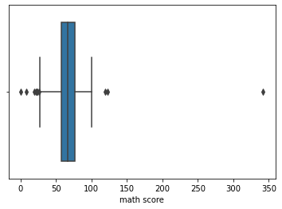

```python
import seaborn as sb
sb.boxplot(x = df['math score'])
```

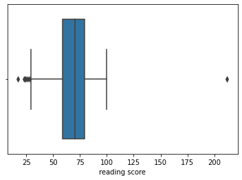

```python
sb.boxplot(x = df['reading score'])
```

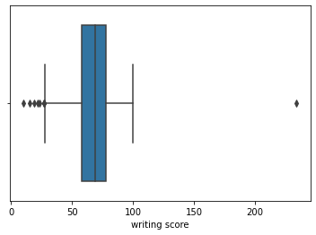

```python
sb.boxplot(x = df['writing score'])
```

#### Steps to perform Outlier Detection by identifying the lowerbound and upperbound of the data:

1. Arrange your data in ascending order
2. Calculate Q1 ( the first Quartile) ==> 25%
3. Calculate Q3 ( the third Quartile) ==> 75%
4. Find IQR = (Q3 - Q1)
5. Find the lower Range = Q1 -(1.5 * IQR)
6. Find the upper Range = Q3 + (1.5 * IQR)

Once you get the upperbound and lowerbound, all you have to do is to delete any values which is less than lowerbound or greater than upperbound.

```python
# df2 will go throuh the outlier removing operations.
df2 = df.copy()
score_col = df2.select_dtypes(['float64']).columns
score_col
```

```
Index(['math score', 'reading score', 'writing score'], dtype='object')
```

```python
# iqr values
from scipy import stats
result_iqr = stats.iqr(df2[score_col], axis = 0)
result_iqr
```

```
array([20., 20., 20.])
```

#### Dropping records with score less than lowerbound = Q1 - (1.5 *IQR) & greater than upperbound = Q3 + (1.5* IQR)

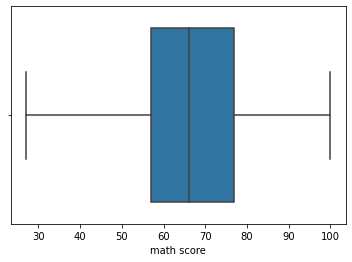

```python
# for math score
df2.drop(df2[df2['math score'] < (df2['math score'].quantile(0.25) - (1.5 * result_iqr[0]))].index, inplace = True)
df2.drop(df2[df2['math score'] > (df2['math score'].quantile(0.75) + (1.5 * result_iqr[0]))].index, inplace = True)
sb.boxplot(x = df2['math score'])
```

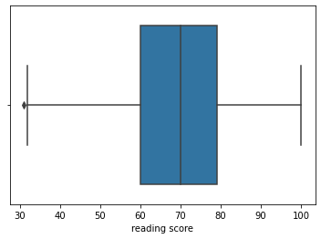

```python
# for reading score
df2.drop(df2[df2['reading score'] < (df2['reading score'].quantile(0.25) - (1.5 * result_iqr[1]))].index, inplace = True)
df2.drop(df2[df2['reading score'] > (df2['reading score'].quantile(0.75) + (1.5 * result_iqr[1]))].index, inplace = True)
sb.boxplot(x = df2['reading score'])
```

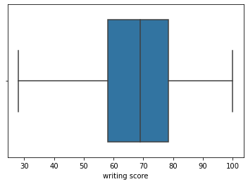

```python
# for writing score
df2.drop(df2[df2['writing score'] < (df2['writing score'].quantile(0.25) - (1.5 * result_iqr[2]))].index, inplace = True)
df2.drop(df2[df2['writing score'] > (df2['writing score'].quantile(0.75) + (1.5 * result_iqr[2]))].index, inplace = True)
sb.boxplot(x = df2['writing score'])
```

```python
df2.shape       # before = (969, 8)
```

```
(951, 8)
```

### 3. to change the scale for better understanding of the variable

```python
df2.describe()
```

|  | math score | reading score | writing score |
| --- | --- | --- | --- |
| count | 951.000000 | 951.000000 | 951.000000 |
| mean | 66.645633 | 69.644388 | 68.496817 |
| std | 14.310691 | 13.874576 | 14.355463 |
| min | 27.000000 | 31.000000 | 28.000000 |
| 25% | 57.000000 | 60.000000 | 58.000000 |
| 50% | 66.000000 | 70.000000 | 69.000000 |
| 75% | 77.000000 | 79.000000 | 78.500000 |
| max | 100.000000 | 100.000000 | 100.000000 |

```python
df2_scale = df2.copy()
df2_feature = df2_scale[score_col]

from sklearn.preprocessing import MinMaxScaler
# x' = ((x - min) /(max - min))*(newmax - newmin) + newmin

scaling = MinMaxScaler(feature_range = (0, 10))                      # points out of 10
df2_scale[score_col] = scaling.fit_transform(df2_feature.values)
df2_scale.head()
```

|  | gender | race/ethnicity | parental level of education | lunch | test preparation course | math score | reading score | writing score |
| --- | --- | --- | --- | --- | --- | --- | --- | --- |
| 0 | female | group B | bachelor's degree | standard | none | 5.410890 | 5.942029 | 6.388889 |
| 1 | female | group C | some college | standard | completed | 5.753425 | 8.550725 | 8.333333 |
| 2 | female | group B | master's degree | standard | none | 8.630137 | 9.275362 | 5.577471 |
| 4 | male | group C | some college | standard | none | 5.410890 | 6.811594 | 6.527778 |
| 5 | female | group B | associate's degree | standard | none | 6.027397 | 7.536232 | 6.944444 |

```python
df2_scale.tail()
```

|  | gender | race/ethnicity | parental level of education | lunch | test preparation course | math score | reading score | writing score |
| --- | --- | --- | --- | --- | --- | --- | --- | --- |
| 995 | female | group E | master's degree | standard | completed | 8.356164 | 9.855072 | 9.305556 |
| 996 | male | group C | high school | free/reduced | none | 4.794521 | 3.478261 | 3.750000 |
| 997 | female | group C | high school | free/reduced | completed | 4.383562 | 5.797101 | 5.138889 |
| 998 | female | group D | some college | standard | completed | 5.616438 | 6.811594 | 6.805556 |
| 999 | female | group D | some college | free/reduced | none | 6.849315 | 7.971014 | 8.055556 |